# results

## Task 1

We have two populations Blue (privileged) and Red (unprivileged), with the Blue population being 9 times larger than the Red population.

Individuals from both populations are requesting to attend XAI training to improve competency in this important area. Number of places is limited. The administrators of the training have decided to give priority to enrolling individuals who may need this training in the future, although unfortunately it is difficult to predict who will benefit.

The decision rule adopted:

1. In the Red group, half of the people will find the skills useful in future and half will not. Administrators randomly allocate 50% of people to training.
2. in the Blue group, 80% of people will find the training useful in future and 20% will not, although of course it is not known who will find it useful. The administrators have built a predictive model based on user behaviour in predicting for whom it will be useful and whom will not. The model has the following performance:

Task: Calculate the Demographic parity, equal opportunity and predictive rate parity coefficients for this decision rule.

Starred task: How can this decision rule be changed to improve its fairness?

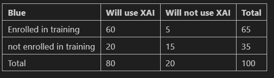

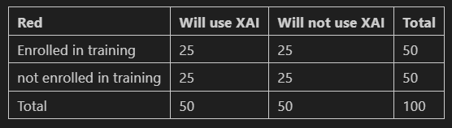

### Demographic parity

$$P(\hat{Y}= 1 | A = blue) = 0.65$$$$P(\hat{Y}= 1 | A = red) = 0.5$$$$DP = 0.5/0.65 = 0.769$$

### Equal opportunity

$$P(\hat{Y}= 1 | Y = \text{use XAI}, A = blue) = 0.75$$$$P(\hat{Y}= 1 | Y = \text{use XAI}, A = red) = 0.5$$$$EO = 0.5/0.75 = 0.667$$

## Task 2

For this homework, train few models on a selected dataset from https://github.com/ahxt/fair_fairness_benchmark/:

Prepare a knitr/jupiter notebook with the following points. Submit your results on GitHub to the directory `Homeworks/HW1`.

1. Train a model for the selected dataset.
2. For the selected protected attribute (age, gender, race) calculate the following fairness coefficients: Statistical parity, Equal opportunity, Predictive parity.
3. Train another model (different hyperparameters, feature transformations etc., different family of models) and see how the coefficients Statistical parity, Equal opportunity, Predictive parity behave for it. Are they different/similar?
4. Apply the selected bias mitigation technique (like data balancing) on the first model. Check how Statistical parity, Equal opportunity, Predictive parity coefficients behave after this mittigation.
5. Compare the quality (performance) of the three models with their fairness coefficients. Is there any correlation/trade off?
6. ! COMMENT on the results obtained in (2)-(5)

### NN

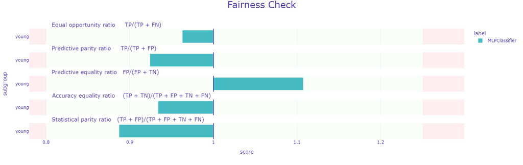

### DT

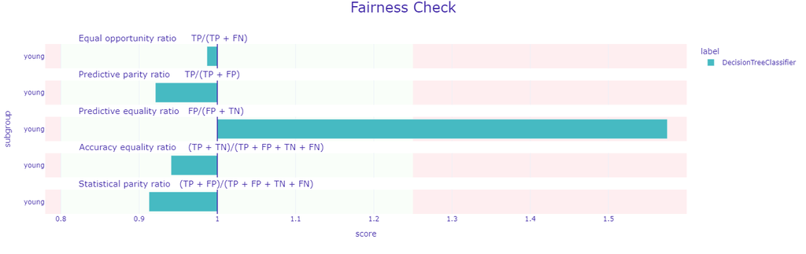

### NN_2

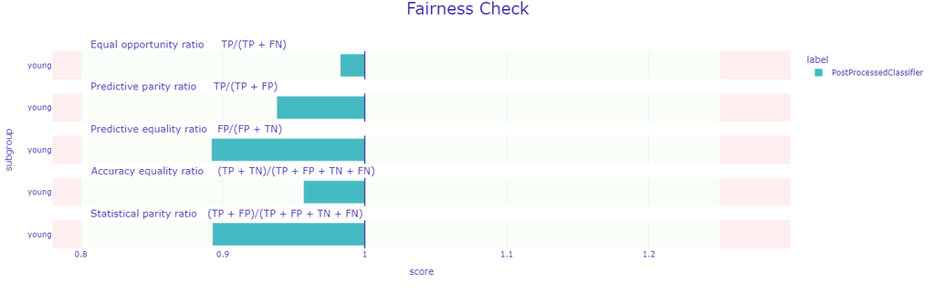

## Comment on results

1. I trained NN and decision tree for protected atribute age

| NN | TPR | ACC | STP |
| --- | --- | --- | --- |
| Young | 0.962963 | 0.933993 | 0.887342 |

| DT | TPR | ACC | STP |
| --- | --- | --- | --- |
| Young | 0.986775 | 0.940928 | 0.912760 |

| NN_2 | TPR | ACC | STP |
| --- | --- | --- | --- |
| Young | 0.982776 | 0.956916 | 0.892729 |

We can see that all off the values of our coefficients increased. Lets now compare the performance of models and their coefficients.

| Model name | TPR | ACC | STP | recall | precision | f1 | accuracy | auc |
| --- | --- | --- | --- | --- | --- | --- | --- | --- |
| NN | 0.962963 | 0.933993 | 0.887342 | 0.960000 | 0.887715 | 0.922443 | 0.887 | 0.951157 |
| DT | 0.986775 | 0.940928 | 0.912760 | 0.978571 | 0.921938 | 0.949411 | 0.927 | 0.981740 |
| NN2 | 0.982776 | 0.956916 | 0.892729 | 0.981429 | 0.852357 | 0.912351 | 0.868 | 0.949438 |

Despite the improvements for Statistical parity, Equal opportunity and Predictive parity between NN and NN_2 auc, acc, f1 and precision diminished. DT has the best scores in TPR and STP as well as auc, acc, prec, f1. It seems that you cannot maximize all of the Statistical parity, Equal opportunity and Predictive parity and performance metric at the same time - there always exists a tradeoff.